# Team Report

Felix Baez-Santiago, Chris Anderson, Austin Nebel

3/5/2021

Imports

```r
library(dplyr)
```

```r
library(ggplot2)
df <- readxl::read_xls("./GSS.xls")
head(df)
```

```
## # A tibble: 6 x 8
##    year id_num Marital_status eduYears Sex    party       happiness   Ballot
##   <dbl>  <dbl> <chr>          <chr>    <chr>  <chr>       <chr>       <chr>
## 1  1972      1 Never married  16       Female Ind,near d… Not too ha… Not appli…
## 2  1972      2 Married        10       Male   Not str de… Not too ha… Not appli…
## 3  1972      3 Married        12       Female Independent Pretty hap… Not appli…
## 4  1972      4 Married        17       Female Not str de… Not too ha… Not appli…
## 5  1972      5 Married        12       Female Strong dem… Pretty hap… Not appli…
## 6  1972      6 Never married  14       Male   Ind,near d… Pretty hap… Not appli…
```

```r
names(df)
```

```
## [1] "year"           "id_num"         "Marital_status" "eduYears"
## [5] "Sex"            "party"          "happiness"      "Ballot"
```

```r
df$highestSchool = as.numeric(as.character(df$eduYears))
```

# Question 1.

Find the average years of education for the respondents with each marital status. Arrange your output in a meaningful order and print. Describe any patterns you find.

```r
data <- filter(df, eduYears != "No answer" & eduYears != "Don't know")

years <- as.numeric(data$eduYears)

data %>%
  group_by(Marital_status) %>%
    summarize(
      year_avg = mean(years))
```

```
## # A tibble: 6 x 2
##   Marital_status year_avg
##   <chr>             <dbl>
## 1 Divorced           12.9
## 2 Married            12.9
## 3 Never married      12.9
## 4 No answer          12.9
## 5 Separated          12.9
## 6 Widowed            12.9
```

# Question 2.

Create a single data frame containing records for the better educated respondents with each marital status. A “better educated” respondent is someone who has strictly more years of education than the average among those with the same marital status. Print the structure of the data frame.

```r
ques2 <- df %>%
  mutate(avg_school_completed = as.numeric(eduYears)) %>%
  na.omit %>%
  group_by(Marital_status) %>%
  summarize(betterEduc = (eduYears > avg_school_completed))
str(ques2)
```

```
## tibble [64,637 × 2] (S3: grouped_df/tbl_df/tbl/data.frame)
##  $ Marital_status: chr [1:64637] "Divorced" "Divorced" "Divorced" "Divorced" ...
##  $ betterEduc    : logi [1:64637] FALSE FALSE FALSE FALSE FALSE FALSE ...
##  - attr(*, "groups")= tibble [6 × 2] (S3: tbl_df/tbl/data.frame)
##   ..$ Marital_status: chr [1:6] "Divorced" "Married" "Never married" "No answer" ...
##   ..$ .rows         : list<int> [1:6]
##   .. ..$ : int [1:8363] 1 2 3 4 5 6 7 8 9 10 ...
##   .. ..$ : int [1:34053] 8364 8365 8366 8367 8368 8369 8370 8371 8372 8373 ...
##   .. ..$ : int [1:13801] 42417 42418 42419 42420 42421 42422 42423 42424 42425 42426 ...
##   .. ..$ : int [1:23] 56218 56219 56220 56221 56222 56223 56224 56225 56226 56227 ...
##   .. ..$ : int [1:2233] 56241 56242 56243 56244 56245 56246 56247 56248 56249 56250 ...
##   .. ..$ : int [1:6164] 58474 58475 58476 58477 58478 58479 58480 58481 58482 58483 ...
##   .. ..@ ptype: int(0)
##   ..- attr(*, ".drop")= logi TRUE
```

# Question 3.

How is the happiness of a respondent related to his/her marriage status? Define that a person is happy if the response to question is “Very happy” or “Pretty happy”.

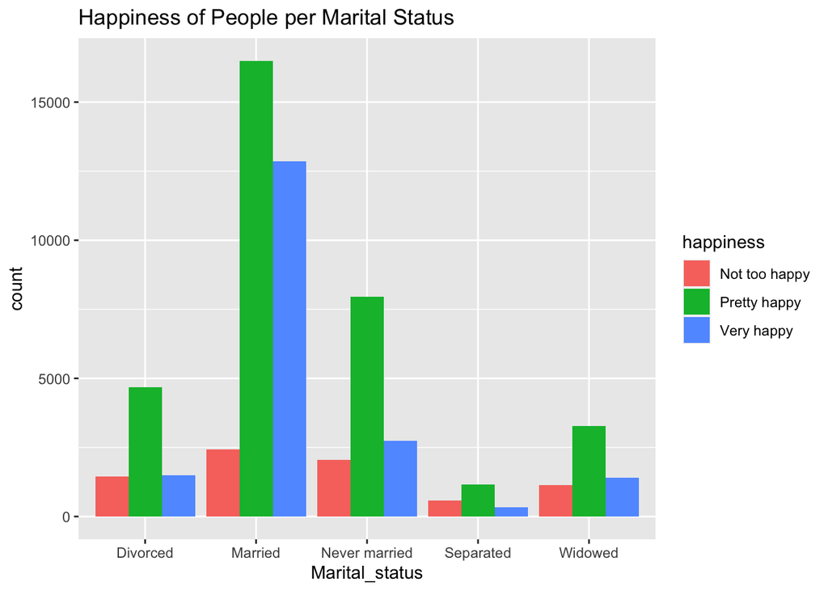

```r
happy <- filter(df, (happiness == "Pretty happy" | happiness == "Very happy" | happiness == "Not too happy") & Marital_status != "No answer")

ggplot(happy, aes(x = Marital_status, fill=happiness)) + geom_histogram(stat="count", position=position_dodge()) + ggtitle('Happiness of People per Marital Status')
```

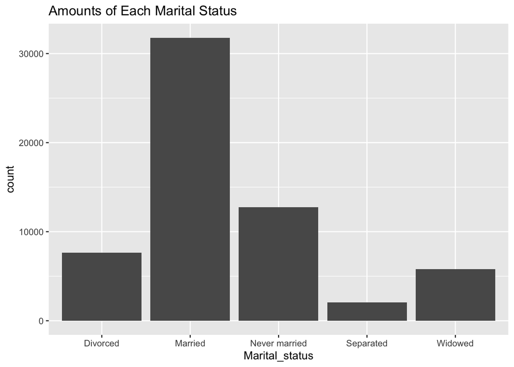

```r
ggplot(happy, aes(x = Marital_status)) + geom_histogram(stat="count", position=position_dodge()) + ggtitle('Amounts of Each Marital Status')
```

There are more married people than all other groups. Every group’s “Pretty happy” rating is higher than their “very happy” rating which is interesting. Separated people have the larges proportion of “Not too happy” compared to others.

# Question 4.

Does party affiliation affect the relationship you found in the last question?

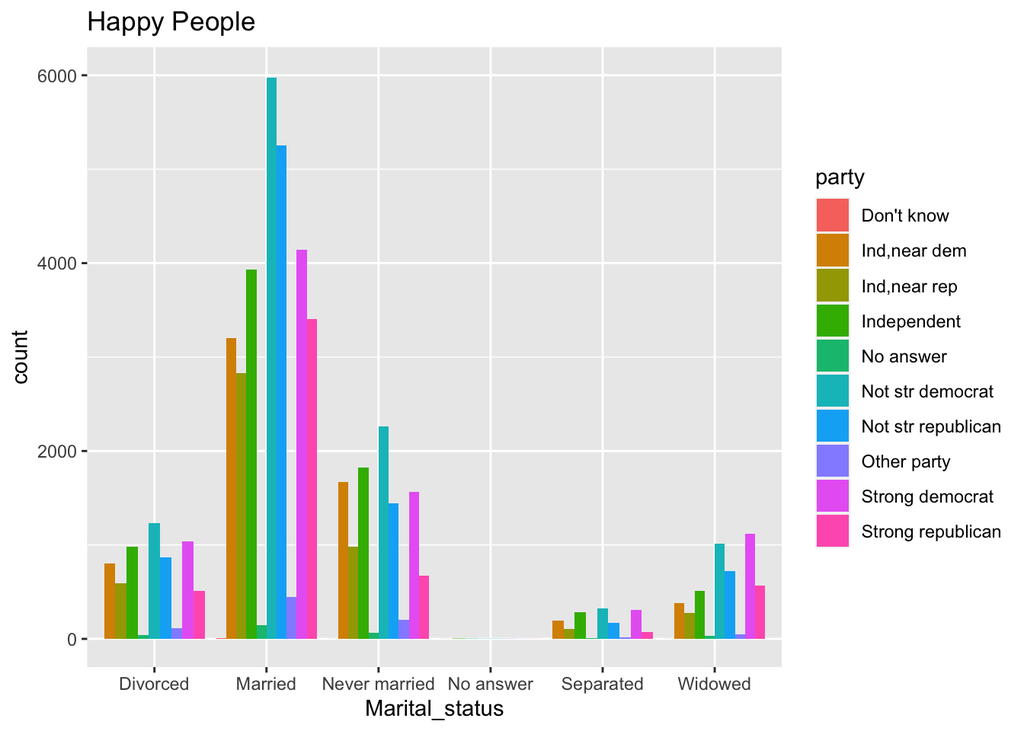

```r
mp <- df[,c("Marital_status","party")]

happy <- filter(df, happiness == "Pretty happy" | happiness == "Very happy")
unhappy <- filter(df, happiness == "Not too happy")

#Respondents that responded Happy
ggplot(happy, aes(x = Marital_status, fill=party)) + geom_histogram(stat="count", position=position_dodge()) + ggtitle('Happy People') + ylim(0,6000)
```

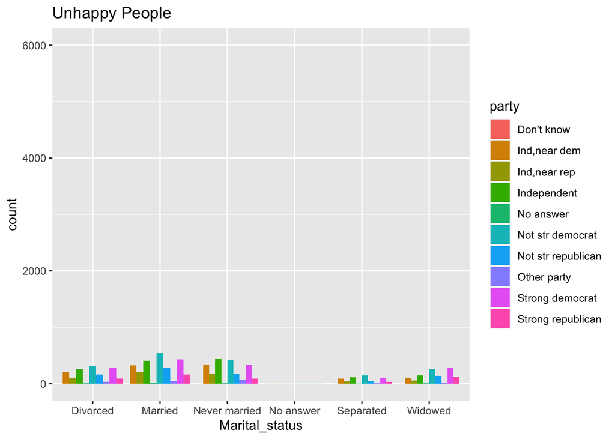

```r
ggplot(unhappy, aes(x = Marital_status, fill=party)) + geom_histogram(stat="count", position=position_dodge()) + ggtitle('Unhappy People') + ylim(0,6000)
```

# Question 5.

How is marital status related to the education of a respondent? What are possible reasons accounting for the patterns you see?

```r
ms_to_years <- df[,c("Marital_status","eduYears")]
ms_to_years <- filter(ms_to_years, eduYears != "No answer" & eduYears != "Don't know")
ms_to_years <- filter(ms_to_years, Marital_status != "No answer")
ms_to_years$eduYears <- as.numeric(ms_to_years$eduYears)
head(ms_to_years)
```

```
## # A tibble: 6 x 2
##   Marital_status eduYears
##   <chr>             <dbl>
## 1 Never married        16
## 2 Married              10
## 3 Married              12
## 4 Married              17
## 5 Married              12
## 6 Never married        14
```

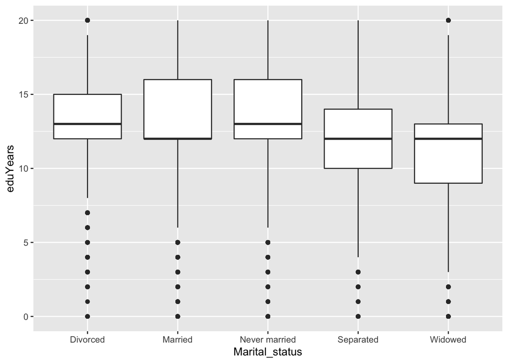

```r
ggplot(ms_to_years, aes(x=Marital_status,y=eduYears)) + geom_boxplot()
```

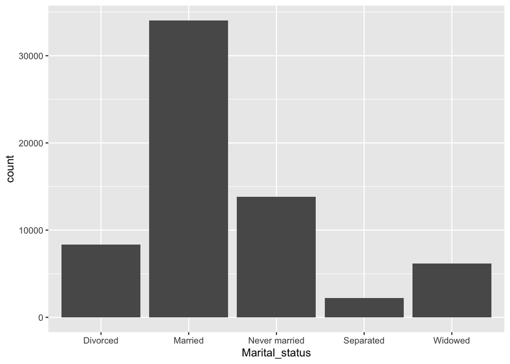

```r
ggplot(ms_to_years, aes(x=Marital_status)) + geom_histogram(stat="count")
```

I noticed that ‘divorced’ and ‘never married’ had the highest averages; this could be because they have more time to themselves and therefore more time to pursue education.

# Question 6.

Explore two more interesting questions, and answer those questions using the GSS data. Question 1: Both genders reported similar levels of happiness.

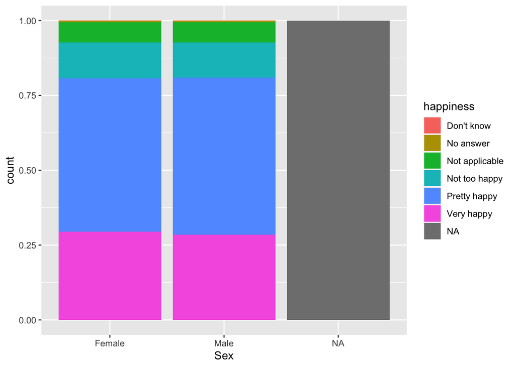

```r
ggplot(df, aes(x=Sex, fill=happiness))+geom_bar(position='fill')
```

Question 2: Both genders have a similar average for highest level of education, but men seem to have a larger range of values.

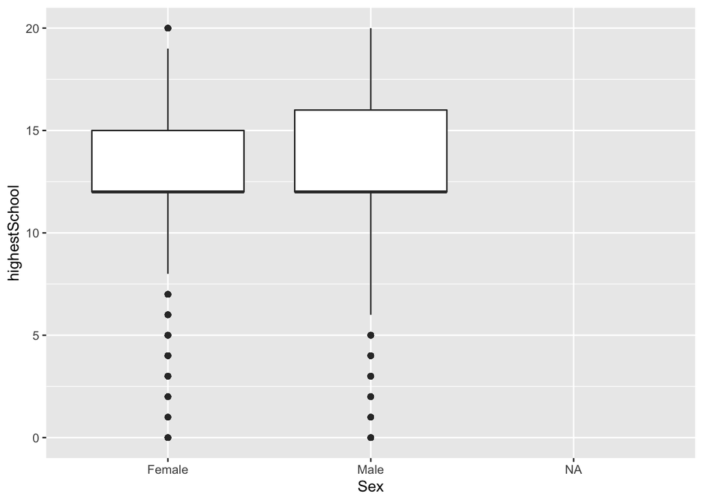

```r
ggplot(df, aes(x=Sex, y=highestSchool))+geom_boxplot()
```